# R course day 3: Plotting

## 4.3 Violin plots

A violin plot is another method of plotting numerical data. The violin plot is similar to box plots, except that they also show the probability density of the data at different values. A violin plot is more informative than a plain boxplot: while a boxplot only shows summary statistics: mean/median, interquartile ranges and outliers, the violin plot shows the full distribution of the data. We can make violin plots using the `geom_violin()` function from **ggplot2**.

**Q16**

- Use the `geom_violin()` function to create a similar plot like the last boxplot (grouped by the measured variables)
- Color the boxes by species and draw actual data points on top of the violin plot
- Add `+ theme(axis.text.x=element_text(angle=45, hjust=1))` to rotate the x-axis labels so they don’t overlap
- The final plot should look like below
- What do you notice in the distribution of the petal length across the three species?

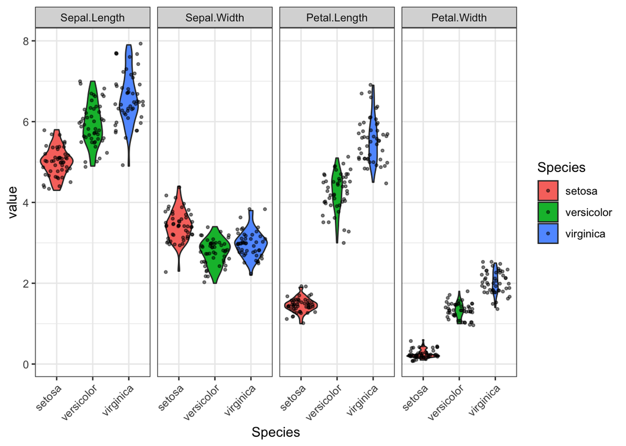

```r
#Question 16
#Code
ggplot(iris.melt, aes(x=Species, y=value, fill=Species)) +
  geom_violin() +
  facet_grid(~variable) +
  geom_point(position = "jitter", alpha=0.5, size=0.8) +
  theme_bw() +
  theme(axis.text.x=element_text(angle=45, hjust=1))
```

```r
#Answer
#The petal length of sentosa has a very small range, and almost all petals are ~1.5cm long
#while this is much more variable for the other two species
```

# 5 Using plots to find anomalies

## 5.1 Coloring points above a threshold

Sometimes you want to quickly see which points are above or below a certain threshold. Coloring these points can be done by first creating a vector with which points you want to color.

You can use the function `ifelse()` to make a vector of outliers vs. non-outliers. `ifelse()` is a function to determine the outcome depending on a condition.

The first argument in the function is what you want to evaluate. For example: for every value in iris$Sepal.Length: is it higher than 7.6 (True) or lower than 7.6 (False)?

The second parameter is the value that it should return if True

The third parameter is the value it should return if False

Here is the example we described:

```r
outlier <- ifelse(iris$Sepal.Length > 7.6, "Outlier", "Non-outlier")
iris$Sepal.Length
```

```
##   [1] 5.1 4.9 4.7 4.6 5.0 5.4 4.6 5.0 4.4 4.9 5.4 4.8 4.8 4.3 5.8 5.7 5.4
##  [18] 5.1 5.7 5.1 5.4 5.1 4.6 5.1 4.8 5.0 5.0 5.2 5.2 4.7 4.8 5.4 5.2 5.5
##  [35] 4.9 5.0 5.5 4.9 4.4 5.1 5.0 4.5 4.4 5.0 5.1 4.8 5.1 4.6 5.3 5.0 7.0
##  [52] 6.4 6.9 5.5 6.5 5.7 6.3 4.9 6.6 5.2 5.0 5.9 6.0 6.1 5.6 6.7 5.6 5.8
##  [69] 6.2 5.6 5.9 6.1 6.3 6.1 6.4 6.6 6.8 6.7 6.0 5.7 5.5 5.5 5.8 6.0 5.4
##  [86] 6.0 6.7 6.3 5.6 5.5 5.5 6.1 5.8 5.0 5.6 5.7 5.7 6.2 5.1 5.7 6.3 5.8
## [103] 7.1 6.3 6.5 7.6 4.9 7.3 6.7 7.2 6.5 6.4 6.8 5.7 5.8 6.4 6.5 7.7 7.7
## [120] 6.0 6.9 5.6 7.7 6.3 6.7 7.2 6.2 6.1 6.4 7.2 7.4 7.9 6.4 6.3 6.1 7.7
## [137] 6.3 6.4 6.0 6.9 6.7 6.9 5.8 6.8 6.7 6.7 6.3 6.5 6.2 5.9
```

```r
outlier
```

```
##   [1] "Non-outlier" "Non-outlier" "Non-outlier" "Non-outlier" "Non-outlier"
##   [6] "Non-outlier" "Non-outlier" "Non-outlier" "Non-outlier" "Non-outlier"
##  [11] "Non-outlier" "Non-outlier" "Non-outlier" "Non-outlier" "Non-outlier"
##  [16] "Non-outlier" "Non-outlier" "Non-outlier" "Non-outlier" "Non-outlier"
##  [21] "Non-outlier" "Non-outlier" "Non-outlier" "Non-outlier" "Non-outlier"
##  [26] "Non-outlier" "Non-outlier" "Non-outlier" "Non-outlier" "Non-outlier"
##  [31] "Non-outlier" "Non-outlier" "Non-outlier" "Non-outlier" "Non-outlier"
##  [36] "Non-outlier" "Non-outlier" "Non-outlier" "Non-outlier" "Non-outlier"
##  [41] "Non-outlier" "Non-outlier" "Non-outlier" "Non-outlier" "Non-outlier"
##  [46] "Non-outlier" "Non-outlier" "Non-outlier" "Non-outlier" "Non-outlier"
##  [51] "Non-outlier" "Non-outlier" "Non-outlier" "Non-outlier" "Non-outlier"
##  [56] "Non-outlier" "Non-outlier" "Non-outlier" "Non-outlier" "Non-outlier"
##  [61] "Non-outlier" "Non-outlier" "Non-outlier" "Non-outlier" "Non-outlier"
##  [66] "Non-outlier" "Non-outlier" "Non-outlier" "Non-outlier" "Non-outlier"
##  [71] "Non-outlier" "Non-outlier" "Non-outlier" "Non-outlier" "Non-outlier"
##  [76] "Non-outlier" "Non-outlier" "Non-outlier" "Non-outlier" "Non-outlier"
##  [81] "Non-outlier" "Non-outlier" "Non-outlier" "Non-outlier" "Non-outlier"
##  [86] "Non-outlier" "Non-outlier" "Non-outlier" "Non-outlier" "Non-outlier"
##  [91] "Non-outlier" "Non-outlier" "Non-outlier" "Non-outlier" "Non-outlier"
##  [96] "Non-outlier" "Non-outlier" "Non-outlier" "Non-outlier" "Non-outlier"
## [101] "Non-outlier" "Non-outlier" "Non-outlier" "Non-outlier" "Non-outlier"
## [106] "Non-outlier" "Non-outlier" "Non-outlier" "Non-outlier" "Non-outlier"
## [111] "Non-outlier" "Non-outlier" "Non-outlier" "Non-outlier" "Non-outlier"
## [116] "Non-outlier" "Non-outlier" "Outlier"     "Outlier"     "Non-outlier"
## [121] "Non-outlier" "Non-outlier" "Outlier"     "Non-outlier" "Non-outlier"
## [126] "Non-outlier" "Non-outlier" "Non-outlier" "Non-outlier" "Non-outlier"
## [131] "Non-outlier" "Outlier"     "Non-outlier" "Non-outlier" "Non-outlier"
## [136] "Outlier"     "Non-outlier" "Non-outlier" "Non-outlier" "Non-outlier"
## [141] "Non-outlier" "Non-outlier" "Non-outlier" "Non-outlier" "Non-outlier"
## [146] "Non-outlier" "Non-outlier" "Non-outlier" "Non-outlier" "Non-outlier"
```

The outlier vector can then be given as a vector to the color parameter. Using `geom_text()` we also add a label to those points.

**Q17**

- Run the code below
- Do you think this cut-off really identifies outliers?

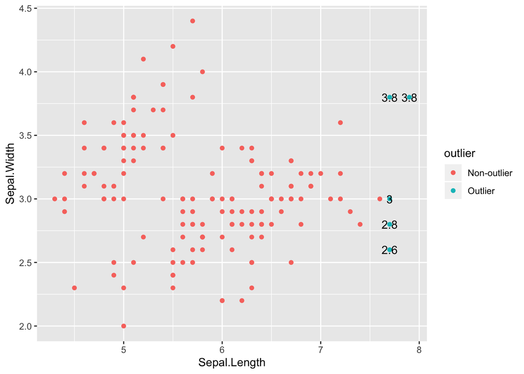

```r
ggplot(iris, aes(x=Sepal.Length, y=Sepal.Width, color=outlier)) +
  geom_point() +
  geom_text(aes(label = Sepal.Width), data = iris[iris$Sepal.Length>7.6,], color="black")
```

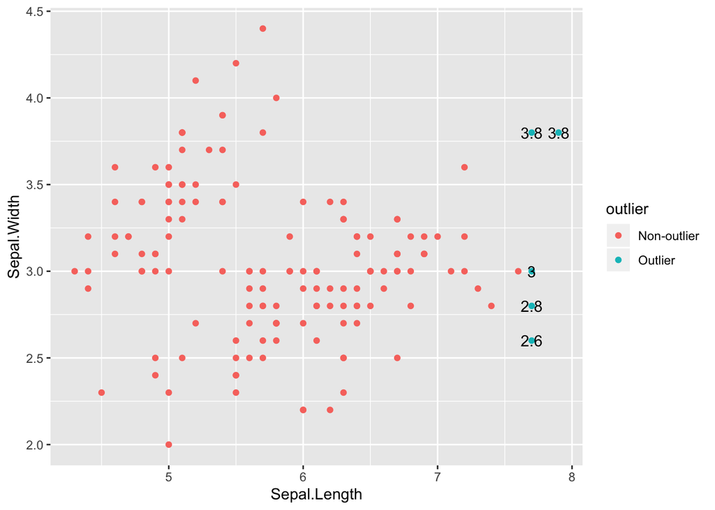

```r
#Question 17
#Code
ggplot(iris, aes(x=Sepal.Length, y=Sepal.Width, color=outlier)) +
  geom_point() +
  geom_text(aes(label = Sepal.Width), data = iris[iris$Sepal.Length>7.6,], color="black")
```

```r
#Answer
#No, these points fit within the distribution of all sepal width values and they should not be marked as outliers.
```

# 6 Simpsons’ paradox

One great way of showing the power of good visualization is Simpsons’ paradox.

Look again at the Iris correlations using `cor(iris[1:4])` and specifically look at the correlation between sepal length and width. As we discussed yesterday, epal width is negatively correlated with sepal length when correlating for all species together, but when correlating using the separate species they are all positive.

**Q18**

- Plot the species sepal length and width using **ggplot2**
- In aesthetics, make x the sepal length and y the sepal width
- Plot the best fitting linear model line by adding `+ geom_smooth(method = "lm")`
- What is the direction of the line? Is that in line with the negative correlation coefficient?

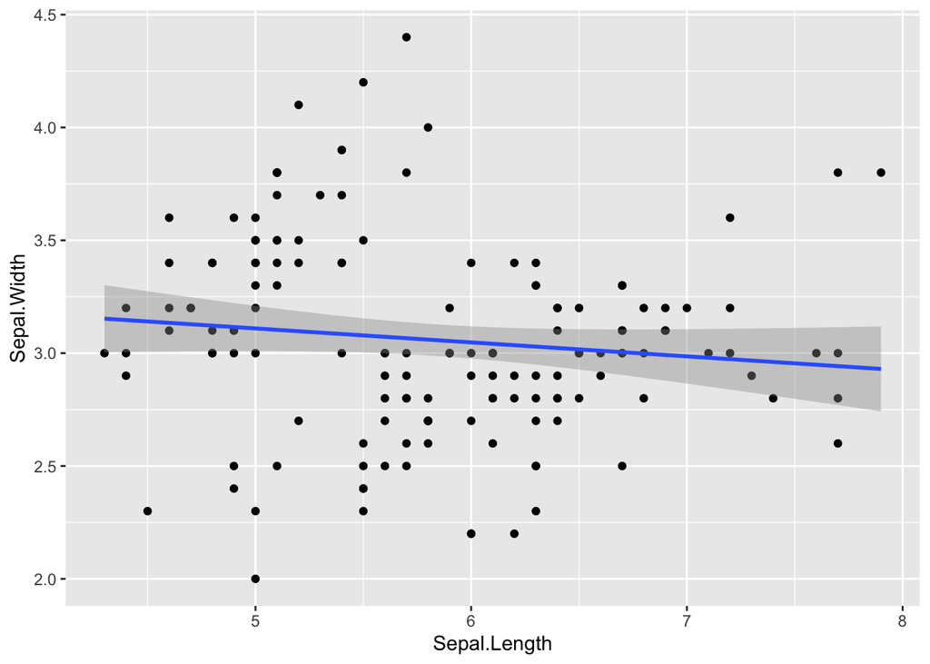

```r
#Question 18
#Code
ggplot(data = iris, aes(x = Sepal.Length, y = Sepal.Width)) +
              geom_point() +
              geom_smooth(method = "lm")
```

```r
#Answer
#The best fitting line is negative, exactly in line with the correlation coefficient
```

**Q19**

- Redo the plot from **Q18** but use `facet_grid()` to split for each species
- Explain the opposite correlation
- Add `scales = "free_x"` as parameter to the `facet_grid()` function
- What is the difference before and after adding this?

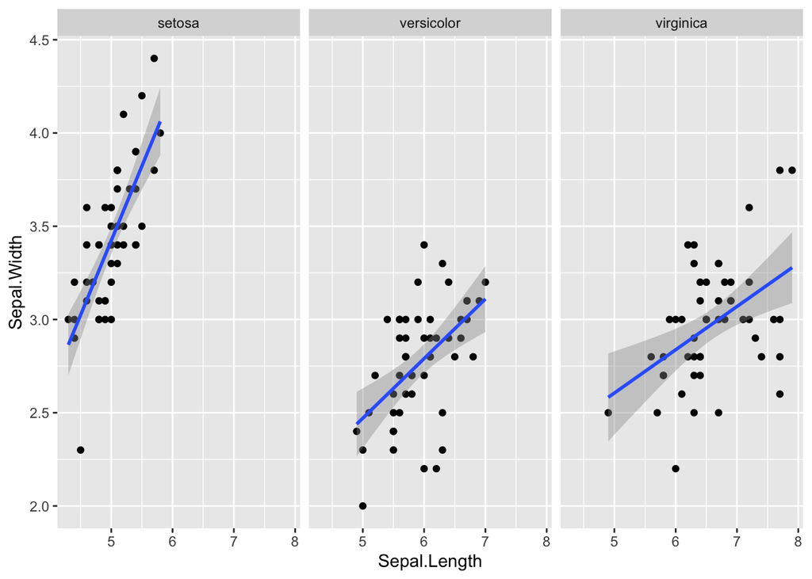

```r
#Question 19
#Code
ggplot(data = iris, aes(Sepal.Length, Sepal.Width)) +
              geom_point() +
              facet_grid(. ~ Species) +
              geom_smooth(method = "lm")
```

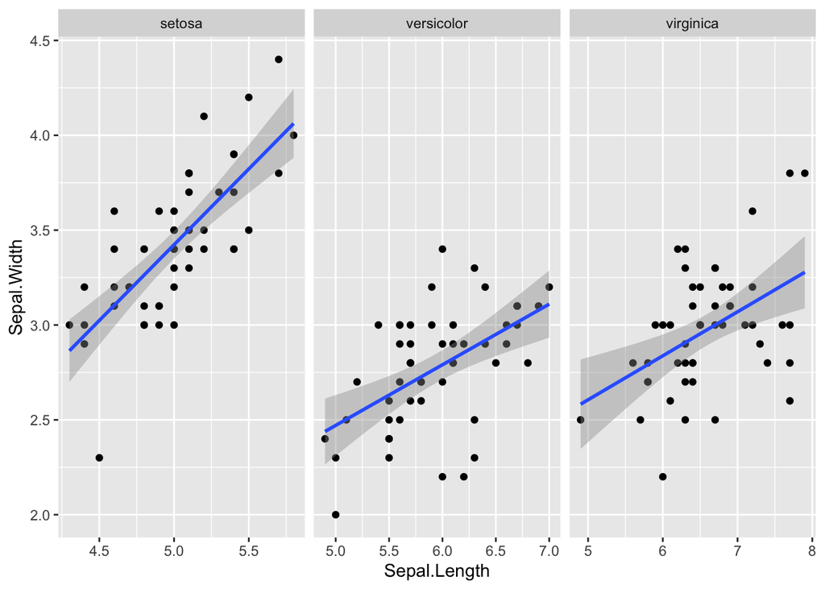

```r
ggplot(data = iris, aes(Sepal.Length, Sepal.Width)) +
              geom_point() +
              facet_grid(. ~ Species, scales = "free_x") +
              geom_smooth(method = "lm")
```

```r
#Answer
#The correlation is positive within each species, but negative when combining all
#This phenomenon is called the Simpsons' paradox
#Adding the free scales means that the three plots do not have to adhere to the same x limits
```

# 7 Saving plots to file

Finally, when you are finished with your plots you will want to save them to a file so that you can add them to your presentation or poster. When using `ggplot()` the easiest way to save is `ggsave()`:

```r
plot1 <- ggplot(data = iris, aes(Sepal.Length, Sepal.Width)) +
  geom_point()

# Running ggsave() will save the last plot you made
ggsave('filename.png')

# The file type is based on the extension you use.
ggsave('filename.pdf')
```

When making figures for posters or presentations, be sure to only use either eps or pdf as these do not lose quality when resizing (read https://thepoliticalmethodologist.com/2013/11/25/making-high-resolution-graphics-for-academic-publishing/ if you want to know more).

You can save a specific plot stored in a variable by adding the parameter `plot=NAME`. In the example below, you are saving `plot1` instead of `plot2`, which would be the case if you didn’t specify that the plot you wanted to save now was `plot=plot1`.

```r
plot2 <- ggplot(data = iris, aes(Sepal.Length, Sepal.Width)) +
            geom_boxplot()

ggsave('filename.pdf', plot=plot1)
```

You will often want to change the width, size and resolution of the plot depending on its use. For presentations when using one figure per slide you want it a bit wider than high, so you can add width and height. For posters you will probably want to use 300 dpi (dots per inch) as your resolution to ensure the plot looks great when printed at high quality.

```r
ggsave('filename.pdf', plot=plot1, dpi=300, width=12, height=8)
```

**Q20**

- Save the last plot you made in **Q19** as a .pdf file
- Use a height of 10 and width of 15
- Run the following two commands:
- Repeat the last command for some more happiness :)

```r
library(praise)
praise()
```